# **Data Exploration**

## **Quick look at the data**

First, let’s load the dataset from `analytical_df_r_to_python.csv` into a DataFrame named `df\` and then proceed to explore the data types of each feature.

The dataframe `df` contains the following features:

```python
# Importing necessary libraries
import pandas as pd
import seaborn as sns
import matplotlib.pyplot as plt
import numpy as np

# Set the theme for seaborn plots
sns.set_theme(style="whitegrid", palette="pastel")

# Load the dataset
df = pd.read_csv("../data-cleaning/outputs/analytical_df_r_to_python.csv")

# Display basic information about the dataset
df.info()
```

```
<class 'pandas.core.frame.DataFrame'>
RangeIndex: 249 entries, 0 to 248
Data columns (total 22 columns):
 #   Column                                  Non-Null Count  Dtype
---  ------                                  --------------  -----
 0   advisory_committee_description          249 non-null    object
 1   statement_or_summary                    244 non-null    object
 2   product_code                            249 non-null    object
 3   zip_code                                248 non-null    object
 4   decision_code                           249 non-null    object
 5   country_code                            249 non-null    object
 6   device_name                             249 non-null    object
 7   advisory_committee                      246 non-null    object
 8   k_number                                249 non-null    object
 9   state                                   248 non-null    object
 10  date_received                           249 non-null    object
 11  review_advisory_committee               249 non-null    object
 12  postal_code                             248 non-null    object
 13  decision_description                    249 non-null    object
 14  clearance_type                          249 non-null    object
 15  CIK                                     249 non-null    int64
 16  SEC_name                                249 non-null    object
 17  financial_year                          249 non-null    int64
 18  GrossProfit                             249 non-null    int64
 19  CostsAndExpenses                        37 non-null     float64
 20  SellingGeneralAndAdministrativeExpense  249 non-null    int64
 21  ProfitLoss                              112 non-null    float64
dtypes: float64(2), int64(4), object(16)
memory usage: 42.9+ KB
```

```python
df.head()
```

|  | advisory_committee_description | statement_or_summary | product_code | zip_code | decision_code | country_code | device_name | advisory_committee | k_number | state | ... | postal_code | decision_description | clearance_type | CIK | SEC_name | financial_year | GrossProfit | CostsAndExpenses | SellingGeneralAndAdministrativeExpense | ProfitLoss |
| --- | --- | --- | --- | --- | --- | --- | --- | --- | --- | --- | --- | --- | --- | --- | --- | --- | --- | --- | --- | --- | --- |
| 0 | Orthopedic | Summary | MQV | 19403 | SESE | US | CONFIRM BIOACTIVE | OR | K133678 | PA | ... | 19403 | Substantially Equivalent | Traditional | 1237831 | GLOBUS MEDICAL, INC. | 2014 | 363514000 | NaN | 187798000 | NaN |
| 1 | Orthopedic | Summary | OWI | 19403 | SESE | US | SILC FIXATION SYSTEM | OR | K133482 | PA | ... | 19403 | Substantially Equivalent | Traditional | 1237831 | GLOBUS MEDICAL, INC. | 2014 | 363514000 | NaN | 187798000 | NaN |
| 2 | Orthopedic | Summary | NKB | 19403 | SESE | US | REVERE STABILIZATION SYSTEM | OR | K133350 | PA | ... | 19403 | Substantially Equivalent | Traditional | 1237831 | GLOBUS MEDICAL, INC. | 2014 | 363514000 | NaN | 187798000 | NaN |
| 3 | Orthopedic | Summary | MAX | 19403 | SESE | US | SUSTAIN AND SUSTAIN RADIOLUCENT SPACERS | OR | K130478 | PA | ... | 19403 | Substantially Equivalent | Traditional | 1237831 | GLOBUS MEDICAL, INC. | 2013 | 334116000 | NaN | 182518000 | NaN |
| 4 | Orthopedic | Summary | OVE | 19403 | SESE | US | COALITION SPACER | OR | K131449 | PA | ... | 19403 | Substantially Equivalent | Traditional | 1237831 | GLOBUS MEDICAL, INC. | 2013 | 334116000 | NaN | 182518000 | NaN |

5 rows × 22 columns

## **Data Understanding**

Now let’s isolate the variables that will be important and most significant to our analysis:

[output not shown]

Now, let’s proceed to rename and reorganize the columns in the dataframe `df` to make it easier to work with. let’s save this new dataframe as `df_analysis`.

```python
# Select specific columns for analysis
df_analysis = df[['device_name', 'SEC_name', 'state', 'CIK', 'financial_year',
                  'GrossProfit', 'CostsAndExpenses', 'SellingGeneralAndAdministrativeExpense',
                  'ProfitLoss', 'advisory_committee_description', 'clearance_type']]

# Rename columns for clarity and brevity
df_analysis = df_analysis.rename(columns={
    'SEC_name': 'company_name',
    'CIK': 'SEC_cik',
    'SellingGeneralAndAdministrativeExpense': 'SG&A',
    'advisory_committee_description': 'advisory_committee'
})

# Convert data types of selected columns
df_analysis['device_name'] = df_analysis['device_name'].astype(str)
df_analysis['company_name'] = df_analysis['company_name'].astype(str)
df_analysis['state'] = df_analysis['state'].astype(str)
df_analysis['SEC_cik'] = df_analysis['SEC_cik'].astype(str)
df_analysis['financial_year'] = df_analysis['financial_year'].astype(str)
df_analysis['GrossProfit'] = df_analysis['GrossProfit'].astype(float)
df_analysis['CostsAndExpenses'] = df_analysis['CostsAndExpenses'].astype(float)
df_analysis['SG&A'] = df_analysis['SG&A'].astype(float)
df_analysis['ProfitLoss'] = df_analysis['ProfitLoss'].astype(float)
df_analysis['advisory_committee'] = df_analysis['advisory_committee'].astype(str)
df_analysis['clearance_type'] = df_analysis['clearance_type'].astype(str)

# Display basic information about the modified dataset
df_analysis.info()

# Save the modified dataset to a CSV file
df_analysis.to_csv("./outputs/analysis.csv", index=False)
```

```
<class 'pandas.core.frame.DataFrame'>
RangeIndex: 249 entries, 0 to 248
Data columns (total 11 columns):
 #   Column              Non-Null Count  Dtype
---  ------              --------------  -----
 0   device_name         249 non-null    object
 1   company_name        249 non-null    object
 2   state               249 non-null    object
 3   SEC_cik             249 non-null    object
 4   financial_year      249 non-null    object
 5   GrossProfit         249 non-null    float64
 6   CostsAndExpenses    37 non-null     float64
 7   SG&A                249 non-null    float64
 8   ProfitLoss          112 non-null    float64
 9   advisory_committee  249 non-null    object
 10  clearance_type      249 non-null    object
dtypes: float64(4), object(7)
memory usage: 21.5+ KB
```

```python
df_analysis.head()
```

|  | device_name | company_name | state | SEC_cik | financial_year | GrossProfit | CostsAndExpenses | SG&A | ProfitLoss | advisory_committee | clearance_type |
| --- | --- | --- | --- | --- | --- | --- | --- | --- | --- | --- | --- |
| 0 | CONFIRM BIOACTIVE | GLOBUS MEDICAL, INC. | PA | 1237831 | 2014 | 363514000.0 | NaN | 187798000.0 | NaN | Orthopedic | Traditional |
| 1 | SILC FIXATION SYSTEM | GLOBUS MEDICAL, INC. | PA | 1237831 | 2014 | 363514000.0 | NaN | 187798000.0 | NaN | Orthopedic | Traditional |
| 2 | REVERE STABILIZATION SYSTEM | GLOBUS MEDICAL, INC. | PA | 1237831 | 2014 | 363514000.0 | NaN | 187798000.0 | NaN | Orthopedic | Traditional |
| 3 | SUSTAIN AND SUSTAIN RADIOLUCENT SPACERS | GLOBUS MEDICAL, INC. | PA | 1237831 | 2013 | 334116000.0 | NaN | 182518000.0 | NaN | Orthopedic | Traditional |
| 4 | COALITION SPACER | GLOBUS MEDICAL, INC. | PA | 1237831 | 2013 | 334116000.0 | NaN | 182518000.0 | NaN | Orthopedic | Traditional |

## **Addressing Missing Values**

Now let’s proceed to address the missing values in the dataframe `df_analysis`. I’ll be using the missingo library to visualize the missing values in the dataframe `df_analysis`.

### **Visualizing Missing Values**

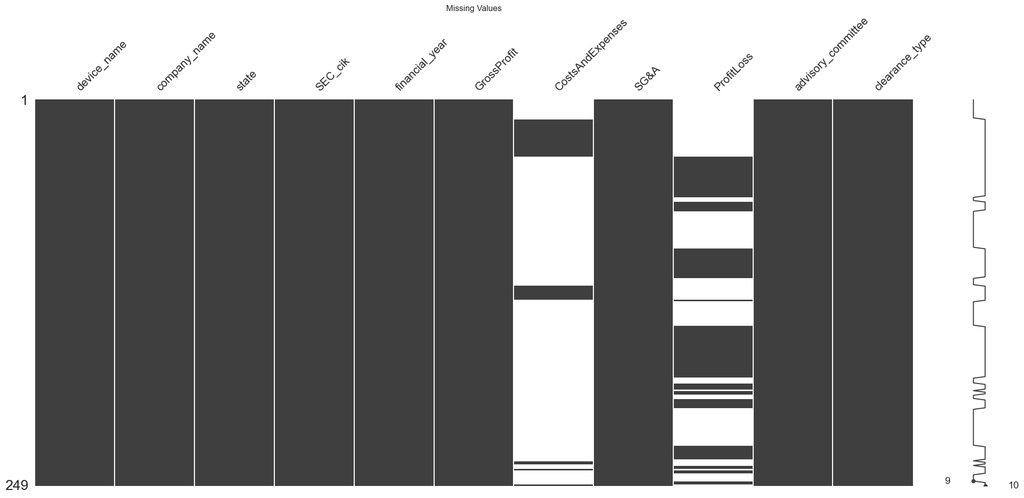

```python
import missingno as msno
msno.matrix(df_analysis)
plt.title('Missing Values')
plt.show()
```

Look’s like there’s a lot of missing values in the `CostAndExpenses` and `ProfitLoss` columns of dataframe `df_analysis`. Let’s proceed to address these missing values by developing an imputation methedology for replacement.

### **Imputing Missing Values**

**Imputing CostsAndExpenses**:

In order to impute values for missing CostsAndExpenses, let’s calculate the median (to avoid skew of mean) ratio of CostsAndExpenses to SG&A from the available data. For rows with missing CostsAndExpenses, let’s use use this ratio to estimate CostsAndExpenses as:

$$Imputed CostsAndExpenses = Median Ratio (\frac{CostsAndExpenses}{SG \& A}) \times SG \& A$$

Similarily, we can extended this process to imputing ProfitLoss with GrossProfit values as follows:

$$Imputed ProfitLoss = Median Ratio (\frac{ProfitLoss}{GrossProfit}) \times GrossProfit$$

```python
imputed_df = df_analysis.copy()

# Calculate the median ratios for imputation
ce_sga_ratio = (imputed_df['CostsAndExpenses'] / df_analysis['SG&A']).median()
pl_gp_ratio = (imputed_df['ProfitLoss'] / df_analysis['GrossProfit']).median()

# Impute missing CostsAndExpenses and ProfitLoss
imputed_df['CostsAndExpenses'] = imputed_df['CostsAndExpenses'].fillna(ce_sga_ratio * df_analysis['SG&A'])
imputed_df['ProfitLoss'] = imputed_df['ProfitLoss'].fillna(pl_gp_ratio * df_analysis['GrossProfit'])

# Check if there are any missing values left in CostsAndExpenses and ProfitLoss
missing_values = imputed_df[['CostsAndExpenses', 'ProfitLoss']].isnull().sum()

missing_values
```

```
CostsAndExpenses    0
ProfitLoss          0
dtype: int64
```

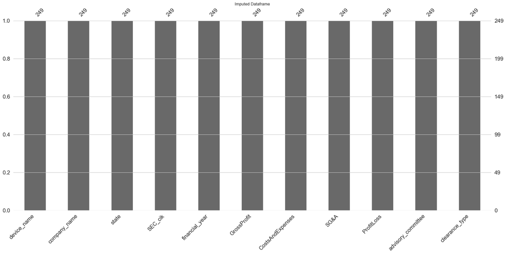

```python
msno.bar(imputed_df,)
plt.title('Imputed Dataframe')
plt.show()
```

## **Quantitative Data Exploration**

Let’s start by first looking at the distribution visualizations, correlations, and descriptive statistics of our quantitative columms (the financial data).

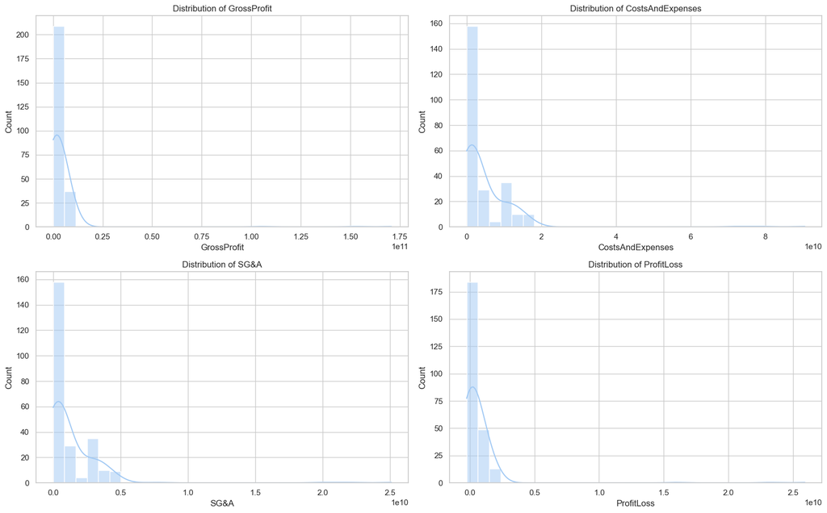

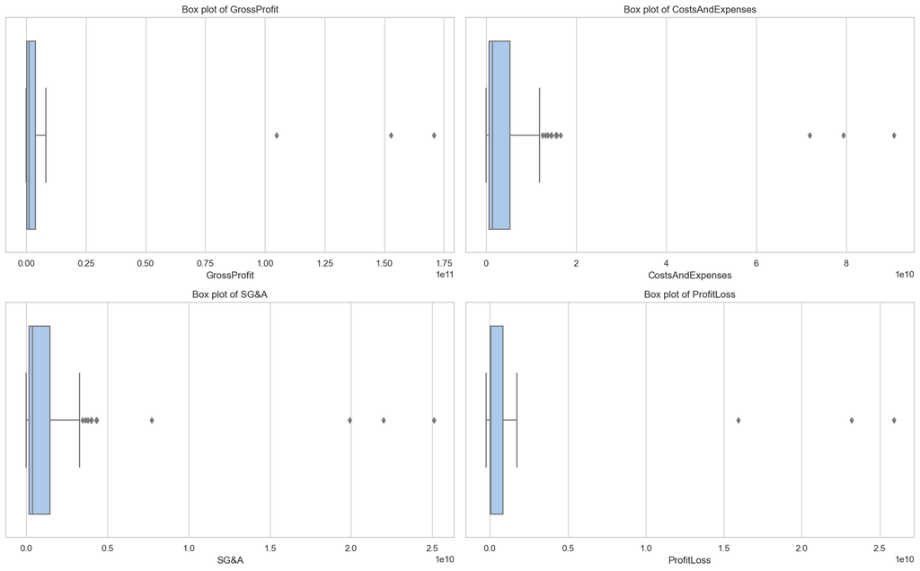

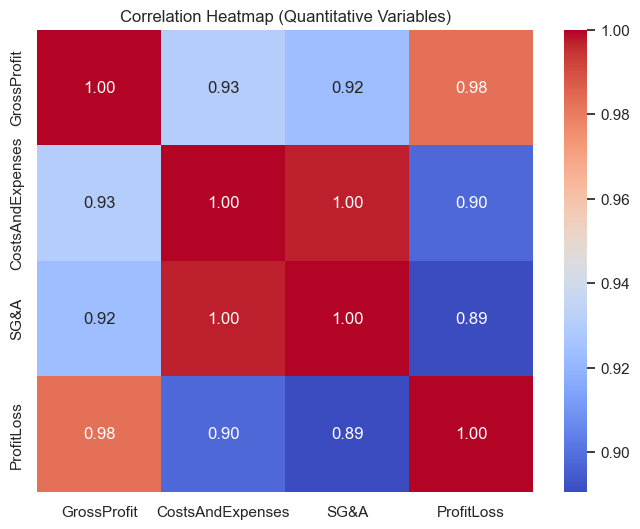

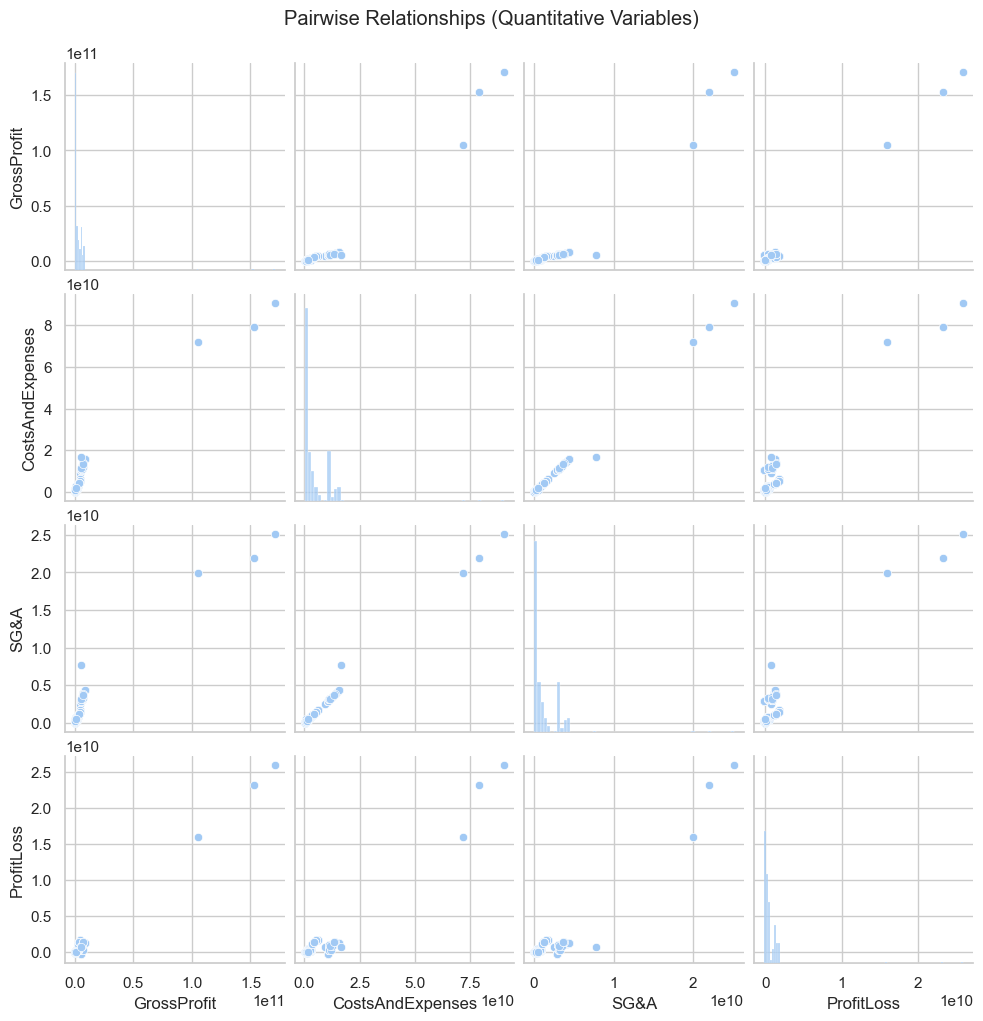

|  | GrossProfit | CostsAndExpenses | SG&A | ProfitLoss |
| --- | --- | --- | --- | --- |
| count | 2.490000e+02 | 2.490000e+02 | 2.490000e+02 | 2.490000e+02 |
| mean | 3.903731e+09 | 4.926535e+09 | 1.375865e+09 | 6.335929e+08 |
| std | 1.587465e+10 | 9.664349e+09 | 2.700608e+09 | 2.438603e+09 |
| min | -1.913000e+06 | 9.512601e+06 | 2.000000e+05 | -2.390000e+08 |
| 25% | 1.763000e+08 | 5.854328e+08 | 1.622270e+08 | 6.220683e+06 |
| 50% | 1.177889e+09 | 1.403794e+09 | 3.890000e+08 | 6.255829e+07 |
| 75% | 3.958500e+09 | 5.292196e+09 | 1.466500e+09 | 8.336716e+08 |
| max | 1.707820e+11 | 9.055736e+10 | 2.509400e+10 | 2.590540e+10 |

```python
# Define the list of quantitative variables
quantitative_vars = ['GrossProfit', 'CostsAndExpenses', 'SG&A', 'ProfitLoss']

# 1. Descriptive Statistics
descriptive_stats_quantitative = imputed_df[quantitative_vars].describe()

# 2. Distribution Visualization: Plot histograms
fig, axes = plt.subplots(nrows=2, ncols=2, figsize=(16, 10))

for idx, var in enumerate(quantitative_vars):
    row, col = divmod(idx, 2)
    sns.histplot(imputed_df[var], bins=30, ax=axes[row, col], kde=True)
    axes[row, col].set_title(f'Distribution of {var}')

plt.tight_layout()
plt.show()

# 3. Box Plots
fig, axes = plt.subplots(nrows=2, ncols=2, figsize=(16, 10))

for idx, var in enumerate(quantitative_vars):
    row, col = divmod(idx, 2)
    sns.boxplot(x=imputed_df[var], ax=axes[row, col])
    axes[row, col].set_title(f'Box plot of {var}')

plt.tight_layout()
plt.show()

# 4. Correlation Analysis: Heatmap
corr_matrix_quantitative = imputed_df[quantitative_vars].corr()
plt.figure(figsize=(8, 6))
sns.heatmap(corr_matrix_quantitative, annot=True, cmap='coolwarm', fmt=".2f")
plt.title("Correlation Heatmap (Quantitative Variables)")
plt.show()

# 5. Pairwise Relationships: Scatter plots
sns.pairplot(imputed_df[quantitative_vars])
plt.suptitle("Pairwise Relationships (Quantitative Variables)", y=1.02)
plt.show()

descriptive_stats_quantitative
```

Great, now let’s interpret the results from each of the visualizations above.

#### **Histograms**

1. **GrossProfit**: The majority of the data points are clustered around the lower values, with a few outliers.
2. **CostsAndExpenses**: Similar to Gross Profit, most values are concentrated at the lower end.
3. **SG&A**: The distribution is skewed to the right, indicating that most companies have lower SG&A expenses.
4. **ProfitLoss**: The distribution is also right-skewed, with most companies having lower profits or losses.

#### **Box Plots**

All these variables have some outliers on the higher end, indicating that some companies have significantly higher values compared to the rest. These are outliers that we’ll have to address and remove in upcoming steps.

### **Removing Outliers**

Now that we’ve visualized our initial dataframe, let’s proceeded to remove outliers and repeat the process using the IQR method.

```python
# Create a copy of the imputed data to avoid modifying the original dataframe
filtered_df = imputed_df.copy()

# Define a function to remove outliers based on IQR method
def remove_outliers(df, column):
    Q1 = df[column].quantile(0.25)
    Q3 = df[column].quantile(0.75)
    IQR = Q3 - Q1
    lower_bound = Q1 - 1.5 * IQR
    upper_bound = Q3 + 1.5 * IQR
    return df[(df[column] >= lower_bound) & (df[column] <= upper_bound)]

# Remove outliers from the selected quantitative variables
for var in quantitative_vars:
    filtered_df = remove_outliers(filtered_df, var)

# Display the first few rows of the filtered data
filtered_df.head()
filtered_df.info()
```

```
<class 'pandas.core.frame.DataFrame'>
Index: 159 entries, 0 to 247
Data columns (total 11 columns):
 #   Column              Non-Null Count  Dtype
---  ------              --------------  -----
 0   device_name         159 non-null    object
 1   company_name        159 non-null    object
 2   state               159 non-null    object
 3   SEC_cik             159 non-null    object
 4   financial_year      159 non-null    object
 5   GrossProfit         159 non-null    float64
 6   CostsAndExpenses    159 non-null    float64
 7   SG&A                159 non-null    float64
 8   ProfitLoss          159 non-null    float64
 9   advisory_committee  159 non-null    object
 10  clearance_type      159 non-null    object
dtypes: float64(4), object(7)
memory usage: 14.9+ KB
```

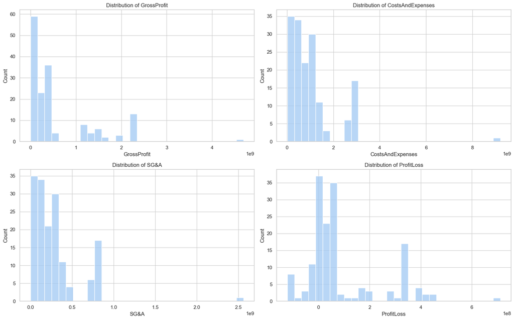

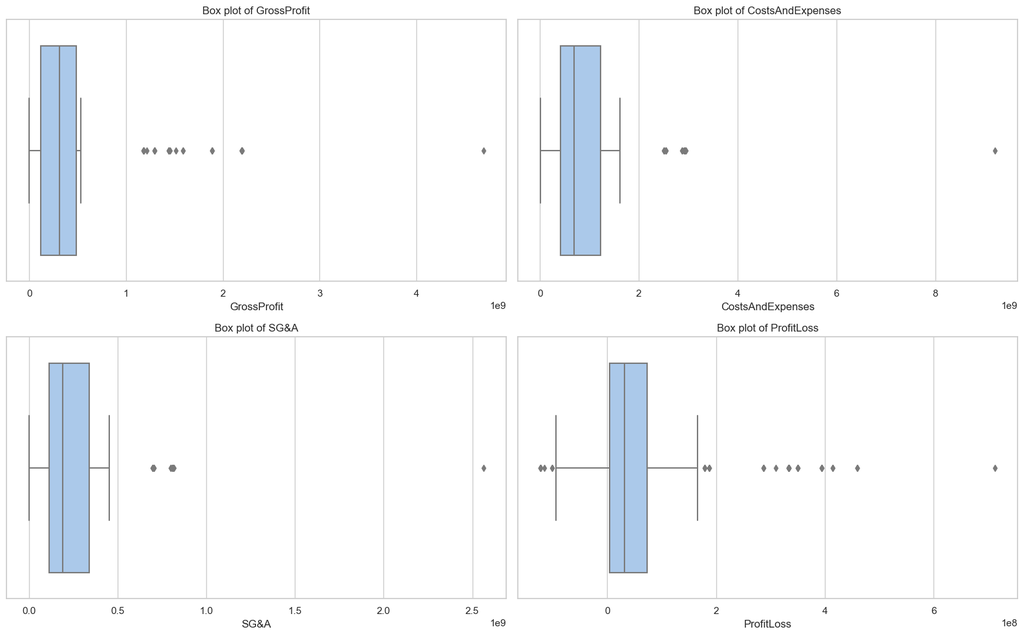

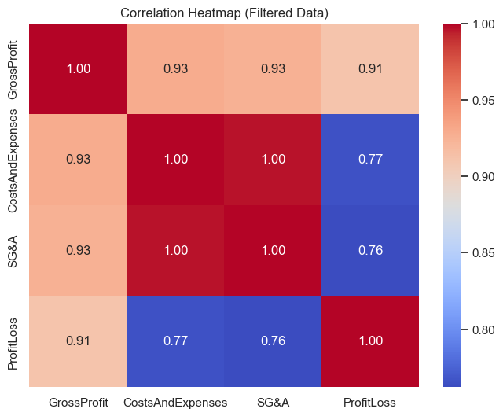

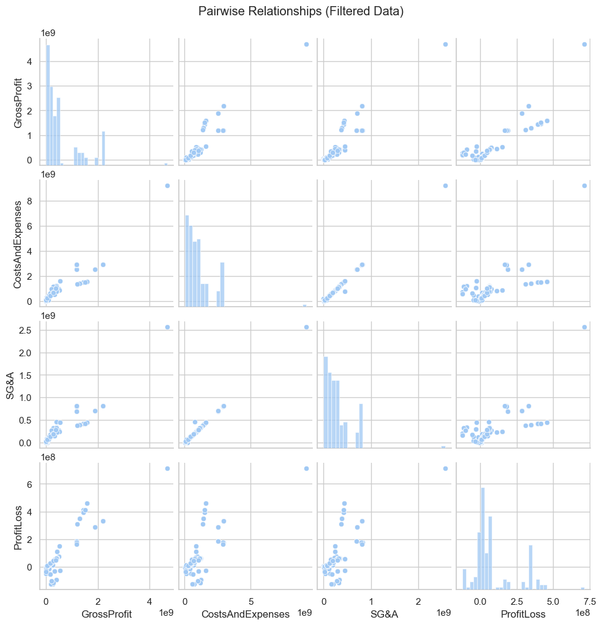

```python
# 2. Distribution Visualization: Plot histograms for filtered data
fig, axes = plt.subplots(nrows=2, ncols=2, figsize=(16, 10))

for idx, var in enumerate(quantitative_vars):
    row, col = divmod(idx, 2)
    sns.histplot(filtered_df[var], bins=30, ax=axes[row, col], kde=True)
    axes[row, col].set_title(f'Distribution of {var}')

plt.tight_layout()
plt.show()

# 3. Box Plots for filtered data
fig, axes = plt.subplots(nrows=2, ncols=2, figsize=(16, 10))

for idx, var in enumerate(quantitative_vars):
    row, col = divmod(idx, 2)
    sns.boxplot(x=filtered_df[var], ax=axes[row, col])
    axes[row, col].set_title(f'Box plot of {var}')

plt.tight_layout()
plt.show()

# 4. Correlation Analysis: Heatmap for filtered data
corr_matrix_filtered = filtered_df[quantitative_vars].corr()
plt.figure(figsize=(8, 6))
sns.heatmap(corr_matrix_filtered, annot=True, cmap='coolwarm', fmt=".2f")
plt.title("Correlation Heatmap (Filtered Data)")
plt.show()

# 5. Pairwise Relationships: Scatter plots for filtered data
sns.pairplot(filtered_df[quantitative_vars])
plt.suptitle("Pairwise Relationships (Filtered Data)", y=1.02)
plt.show()
```

**Histograms**: The histograms show the distributions of each variable. Most distributions are right-skewed, indicating that most companies have lower values, with a few having much higher values.

**Box Plots**: These plots provide insights into the spread of the data and potential outliers. Even with the removal of previous outliers, new ones still remain, but we’ll continue with our analysis keeping these in mind.

**Correlation Heatmap**: The heatmap shows the correlation between the variables. Notably, there is a strong positive correlation between **CostsAndExpenses** and **SG&A**.

**Pairwise Relationships**: The scatter plots reveal relationships between pairs of variables. For instance, the scatter plots between **CostsAndExpenses** and **SG&A** indicate a linear relationship.

## **Categorical Variables**

Now that we’ve conducted our analysis on the initial quantitative variables, let’s proceed to explore the categorical variables in the dataframe `filtered_df`.

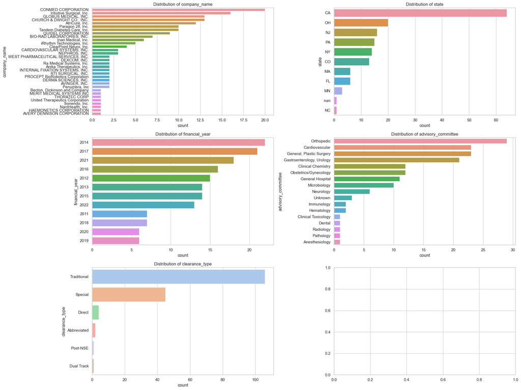

```python
# Define the list of qualitative variables
qualitative_vars = ['company_name', 'state', 'financial_year', 'advisory_committee', 'clearance_type']

# 2. Data Visualization: Plot bar charts for qualitative variables
fig, axes = plt.subplots(nrows=3, ncols=2, figsize=(20, 15))

for idx, var in enumerate(qualitative_vars):
    row, col = divmod(idx, 2)
    sns.countplot(y=filtered_df[var], ax=axes[row, col], order=filtered_df[var].value_counts().index)
    axes[row, col].set_title(f'Distribution of {var}')

plt.tight_layout()
plt.show()
```

```python
for i in qualitative_vars:
    print(filtered_df[i].value_counts().reset_index())
    print('\n')
```

```
                          company_name  count
0                   CONMED CORPORATION     20
1             Intuitive Surgical, Inc.     16
2                 GLOBUS MEDICAL, INC.     13
3            CHURCH & DWIGHT CO., INC.     13
4                       AtriCure, Inc.     12
5                     Paragon 28, Inc.     10
6           Tandem Diabetes Care, Inc.     10
7                   QUIDEL CORPORATION      9
8           BIO-RAD LABORATORIES, INC.      7
9                  Inari Medical, Inc.      6
10          iRhythm Technologies, Inc.      5
11              ClearPoint Neuro, Inc.      4
12        CARDIOVASCULAR SYSTEMS, INC.      3
13                       NEPHROS, INC.      3
```

[output cut: 76 more lines]

## **More quantitative visualizations**

```python
def pd_general_plots(df,HUE=None):
    #NOTE: CERTAIN PLOTS ONLY WORK IF HUE=CATERGORICAL

    #-------------------------
    #FULL PAIR PLOT
    #-------------------------
    sns.pairplot(df, diag_kind='kde', kind="hist", hue=HUE)  # SLOWER
    plt.show()

    #-------------------------
    #DENSITY PLOT PROJECTED ONTO FIRST COL
    #-------------------------

    if(HUE!=None):
        #GET NAME OF FIRST COLUMN
        colname = df.columns[0]

        # Plot the distribution of clarity ratings, conditional on carat
        sns.displot(
            data=df,
            x=colname, hue=HUE,
            kind="kde", height=6,
            multiple="fill", alpha=.5,    palette="ch:rot=-.25,hue=1,light=.5",

        )
        plt.show()

    #-------------------------
    #VIOLIN PLOTS
    #-------------------------
    f, ax = plt.subplots(figsize=(7, 6))
    sns.set_theme()
    sns.violinplot(data=df, palette="Set3", inner="points", orient="h")
    plt.show()
```

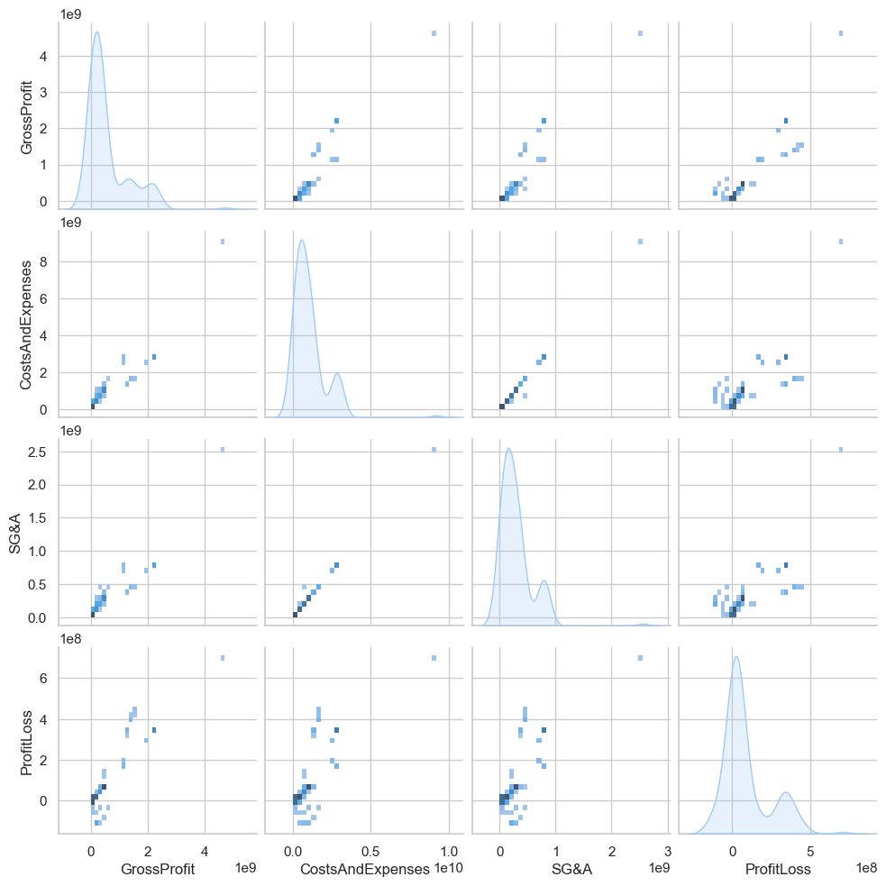

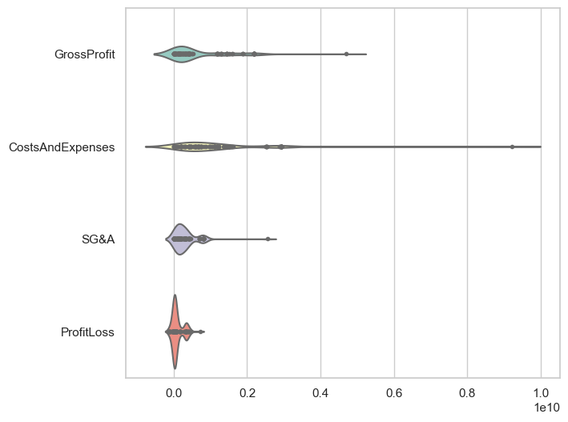

```python
pd_general_plots(filtered_df[['GrossProfit', 'CostsAndExpenses', 'SG&A', 'ProfitLoss']])
```

```python
def pandas_2D_plots(df,col_to_plot=[0,1,2], HUE=None):

    #NOTES:
    # X=NUMERIC CONTINUOUS col_to_plot[0]
    # Y=NUMERIC CONTINUOUS col_to_plot[1]
    # Z=NUMERIC CONTINUOUS col_to_plot[2] (USED FOR SIZE AND COLORING)

    # HUE=DISCRETE OR CATEGORICAL

    #GET COLUMN NAMES FOR PLOTTING
    xname=df.columns[col_to_plot[0]]
    yname=df.columns[col_to_plot[1]]
    zname=df.columns[col_to_plot[2]]
    # print(xname,yname,zname); exit()

    #ERROR CHECK
    if(str(type(df)) != "<class 'pandas.core.frame.DataFrame'>"):
        raise ValueError("input variable is not panda DataFrame")

    if(len(df.columns)<3): raise ValueError("not enough columns")
    #print("number of col:",  len(df.columns))


    # #-------------------------
    # #SCATTER PLOT
    # #-------------------------
    plt.figure(figsize=(12,8))
    sns.scatterplot(x=xname,y=yname,data=df,hue=HUE)
    plt.show()

    sns.scatterplot(x=xname,y=yname,data=df,hue=zname) #HUE CAN BE
    sns.kdeplot(x=xname,y=yname,data=df, levels=5, color="b", linewidths=1)
    plt.show()

    sns.scatterplot(x=xname,y=yname,data=df,hue=HUE,size=zname) #HUE CAN BE
    plt.show()


    #-------------------------
    #VARIOUS PAIR PLOT STYLES
    #-------------------------
    keys_to_plot=index_to_keys(df,col_to_plot)

    if(HUE!=None and HUE not in keys_to_plot): keys_to_plot.append(HUE)
    print("keys_to_plot",keys_to_plot)

    sns.pairplot(df[keys_to_plot], kind='kde',hue=HUE)       #VERY SLOW BUT LOOKS GOOD
    plt.show()

    sns.pairplot(df[keys_to_plot], diag_kind='kde',hue=HUE)  #FAST
    plt.show()

    plt1=sns.pairplot(df[keys_to_plot], diag_kind='kde',hue=HUE)  #FAST
    plt1.map_lower(sns.kdeplot, levels=4, color=".2")  #SLOWER BUT BETTER
    plt.show()


    #-------------------------
    #JOINTPLOT
    #-------------------------
    # Show the joint distribution using kernel density estimation
    sns.jointplot(
        data=df,
        x=xname, y=yname,
        kind="kde", hue=HUE
    )
    plt.show()


    # #-------------------------
    # #BOX AND WHISKER
    # #-------------------------
    # #ONLY WORKS FOR CATEGORICAL HUE
    if(HUE!=None):
        for name in [xname,yname]:
            # Plot the orbital period with horizontal boxes
            sns.boxplot(x=name, y=HUE, data=df,
                        whis=[0, 100], width=.6, palette="vlag")

            # # Add in points to show each observation
            sns.stripplot(x=name, y=HUE, data=df,
                          size=4, color=".3", linewidth=0)
            plt.show()


            sns.boxenplot(x=HUE, y=name,
                      color="b",
                      scale="linear", data=df)
            plt.show()

            #SWARM PLOT
            ax = sns.swarmplot(data=df, x=xname, y=HUE, hue=HUE)
            ax.set(ylabel="")
            plt.show()


    #-------------------------
    #RELPLOT
    #-------------------------

    sns.relplot(x=xname, y=yname, hue=HUE, size=zname,
            sizes=(40, 400), alpha=.5, palette="muted",
            height=6, data=df)
    plt.show()
```

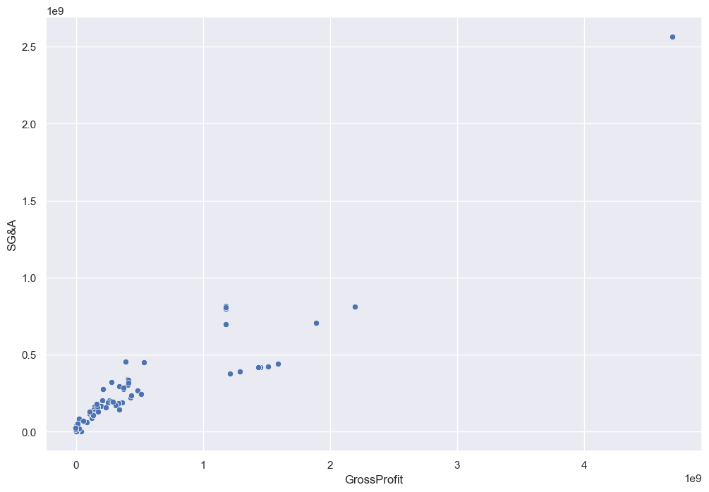

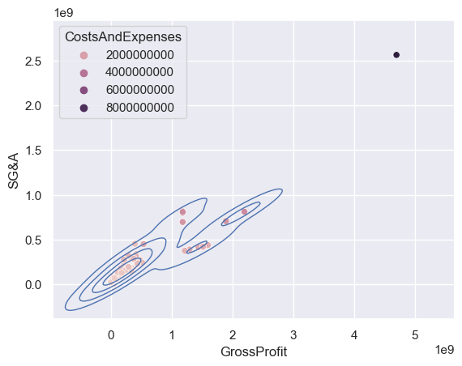

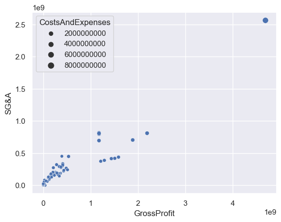

```
keys_to_plot ['GrossProfit', 'SG&A', 'CostsAndExpenses']
```

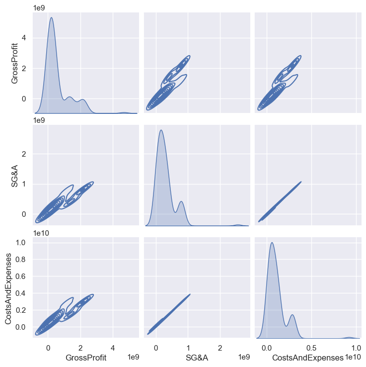

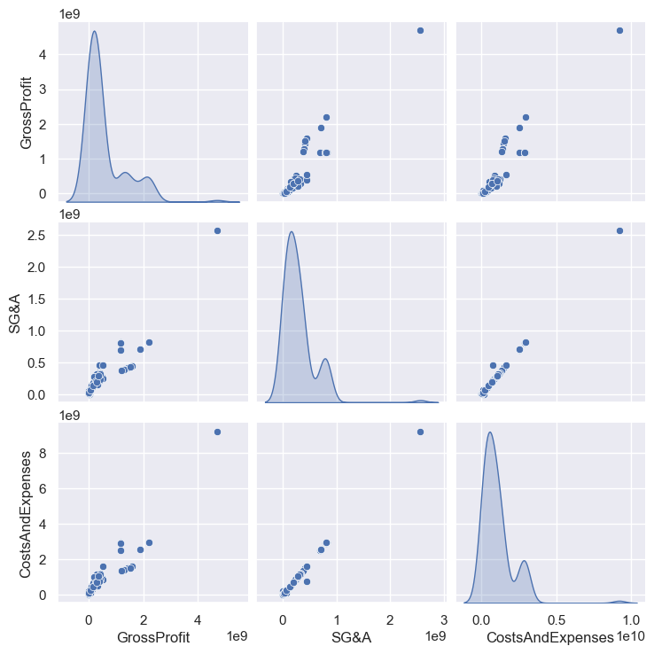

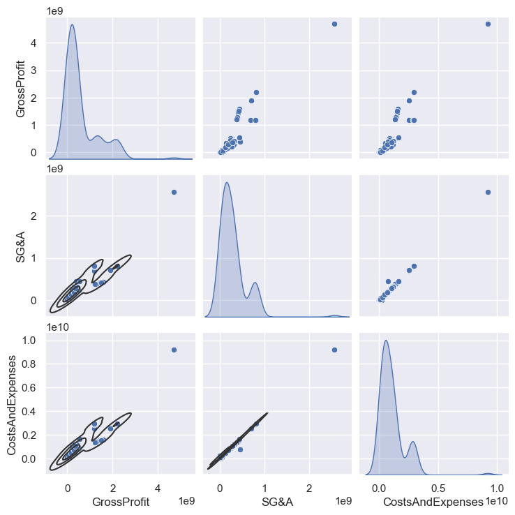

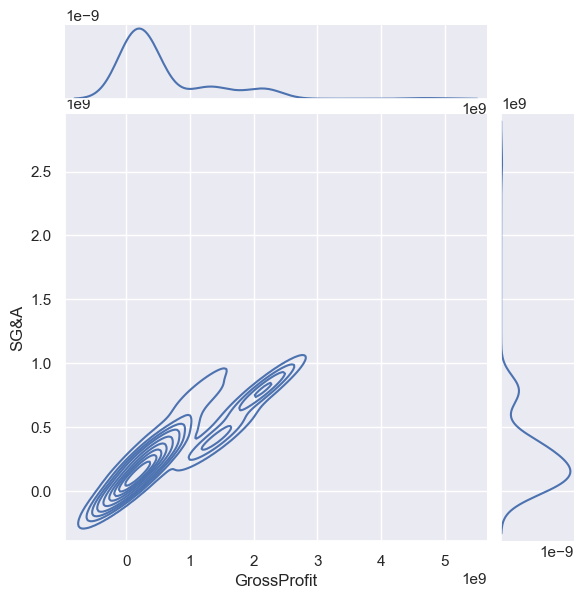

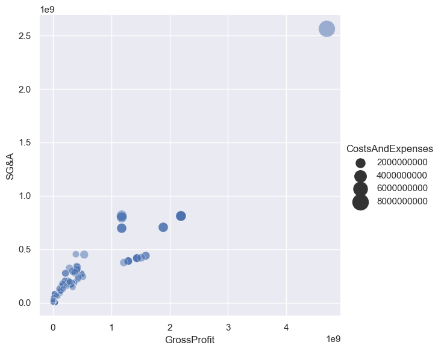

```python
# RUN FUNCTION
pandas_2D_plots(filtered_df[['GrossProfit', 'SG&A','CostsAndExpenses','ProfitLoss']])
```

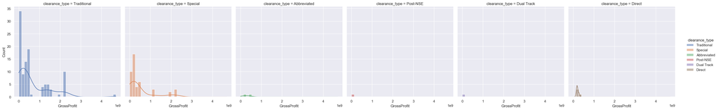

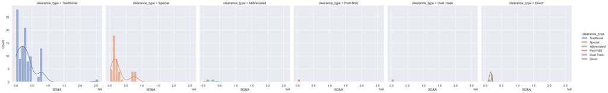

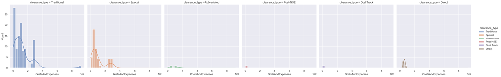

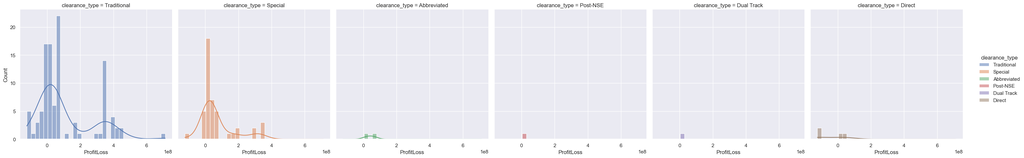

```python
sns.displot(
    data=filtered_df,
    x="GrossProfit",
    col="clearance_type",
    hue="clearance_type",
    kde=True
    )
plt.show()

sns.displot(
    data=filtered_df,
    x="SG&A",
    col="clearance_type",
    hue="clearance_type",
    kde=True
    )
plt.show()

sns.displot(
    data=filtered_df,
    x="CostsAndExpenses",
    col="clearance_type",
    hue="clearance_type",
    kde=True
    )
plt.show()

sns.displot(
    data=filtered_df,
    x="ProfitLoss",
    col="clearance_type",
    hue="clearance_type",
    kde=True
    )
plt.show()
```

```python
filtered_df.to_csv("./outputs/filtered.csv", index=False)
```

The above visualizations seem to continue to show the skewed nature of the data, with a lack of data for many categories. For my next steps, I’ll be looking into ways that we can address the lack of substantial data in order to glean the most possible out of the analysis.

## **Discussion**

#### **Key Findings:**

**Financial Metrics and Clearance Types** - There may be a potential relationship between clearance types and financial metrics, indicating that that the type of clearance might be indicative of financial performance of a company.

**Advisory Committees** - The association between advisory committees and financial metrics should be further explored as financial performance of companies may be correlated to what industries they develop technology for.

**Data Quality and Outliers** - The presence of outliers and missing values in the initial dataset highlighted the need for data cleaning and imputation. By addressing these issues, the subsequent analysis was based on a better dataset, but lost significant data in the process.

#### **Hypotheses for Future Exploration**

- My obersevations for the EDA has led me to generate hypotheses related to the influence of clearance types, geographical location, and advisory committees on financial metrics. I believe that there is a strong association between financial metrics and the clearance types, geographical location, and advisory committees for a company’s filed devices, indicating that knowing one set may have the potential to predict the other.